# Final Project - Macia - 5 - K-means

Maçià Bartomeu Llabrés Ferrer

2023-01-26

We start by loading the previous “prep” file and check if the data is the same.

```r
df <- read.csv("FPdata_NOR.csv", stringsAsFactors = TRUE)
str(df)
```

```
## 'data.frame':    412478 obs. of  40 variables:
##  $ State                    : num  0 0 0 0 0 0 0 0 0 0 ...
##  $ Gender                   : int  0 0 0 0 0 1 0 0 0 0 ...
##  $ GeneralHealth            : num  0.75 1 0.75 1 0.25 0 0.75 0.5 0.5 0.5 ...
##  $ PhysicalHealthDays       : num  0 0 0.0667 0 0.0667 ...
##  $ MentalHealthDays         : num  0 0 0.1 0 0 0 0 0 0 0 ...
##  $ LastCheckupTime          : num  1 0 1 1 1 1 1 1 1 1 ...
##  $ PhysicalActivities       : int  0 0 1 1 1 0 1 0 1 1 ...
##  $ SleepHours               : num  0.304 0.217 0.174 0.261 0.348 ...
##  $ RemovedTeeth             : int  1 1 1 1 1 1 1 1 1 1 ...
##  $ HadHeartAttack           : int  0 0 0 0 0 1 0 0 0 0 ...
##  $ HadAngina                : int  0 0 0 0 0 0 0 0 0 0 ...
##  $ HadStroke                : int  0 0 0 0 0 1 0 0 0 0 ...
##  $ HadAsthma                : int  0 0 0 1 0 0 0 0 0 0 ...
##  $ HadSkinCancer            : int  0 1 1 0 0 0 0 0 1 0 ...
```

[output cut: 26 more lines]

```r
summary(df)
```

```
##      State            Gender       GeneralHealth    PhysicalHealthDays
##  Min.   :0.0000   Min.   :0.0000   Min.   :0.0000   Min.   :0.0000
##  1st Qu.:0.2830   1st Qu.:0.0000   1st Qu.:0.5000   1st Qu.:0.0000
##  Median :0.4906   Median :0.0000   Median :0.7500   Median :0.0000
##  Mean   :0.5172   Mean   :0.4719   Mean   :0.6168   Mean   :0.1356
##  3rd Qu.:0.7925   3rd Qu.:1.0000   3rd Qu.:0.7500   3rd Qu.:0.1000
##  Max.   :1.0000   Max.   :1.0000   Max.   :1.0000   Max.   :1.0000
##  MentalHealthDays LastCheckupTime  PhysicalActivities   SleepHours
##  Min.   :0.0000   Min.   :0.0000   Min.   :0.0000     Min.   :0.0000
##  1st Qu.:0.0000   1st Qu.:1.0000   1st Qu.:1.0000     1st Qu.:0.2174
##  Median :0.0000   Median :1.0000   Median :1.0000     Median :0.2609
##  Mean   :0.1385   Mean   :0.8881   Mean   :0.7699     Mean   :0.2624
##  3rd Qu.:0.1333   3rd Qu.:1.0000   3rd Qu.:1.0000     3rd Qu.:0.3043
##  Max.   :1.0000   Max.   :1.0000   Max.   :1.0000     Max.   :1.0000
##   RemovedTeeth    HadHeartAttack     HadAngina         HadStroke
##  Min.   :0.0000   Min.   :0.0000   Min.   :0.00000   Min.   :0.00000
##  1st Qu.:0.0000   1st Qu.:0.0000   1st Qu.:0.00000   1st Qu.:0.00000
##  Median :0.0000   Median :0.0000   Median :0.00000   Median :0.00000
##  Mean   :0.4707   Mean   :0.0558   Mean   :0.05887   Mean   :0.04267
##  3rd Qu.:1.0000   3rd Qu.:0.0000   3rd Qu.:0.00000   3rd Qu.:0.00000
##  Max.   :1.0000   Max.   :1.0000   Max.   :1.00000   Max.   :1.00000
##    HadAsthma      HadSkinCancer        HadCOPD        HadDepressiveDisorder
##  Min.   :0.0000   Min.   :0.00000   Min.   :0.00000   Min.   :0.0000
##  1st Qu.:0.0000   1st Qu.:0.00000   1st Qu.:0.00000   1st Qu.:0.0000
##  Median :0.0000   Median :0.00000   Median :0.00000   Median :0.0000
##  Mean   :0.1443   Mean   :0.08153   Mean   :0.07701   Mean   :0.1992
##  3rd Qu.:0.0000   3rd Qu.:0.00000   3rd Qu.:0.00000   3rd Qu.:0.0000
##  Max.   :1.0000   Max.   :1.00000   Max.   :1.00000   Max.   :1.0000
##  HadKidneyDisease   HadArthritis     HadDiabetes     DeafOrHardOfHearing
##  Min.   :0.00000   Min.   :0.0000   Min.   :0.0000   Min.   :0.00000
##  1st Qu.:0.00000   1st Qu.:0.0000   1st Qu.:0.0000   1st Qu.:0.00000
##  Median :0.00000   Median :0.0000   Median :0.0000   Median :0.00000
##  Mean   :0.04436   Mean   :0.3335   Mean   :0.1389   Mean   :0.08687
##  3rd Qu.:0.00000   3rd Qu.:1.0000   3rd Qu.:0.0000   3rd Qu.:0.00000
##  Max.   :1.00000   Max.   :1.0000   Max.   :1.0000   Max.   :1.00000
##  BlindOrVisionDifficulty DifficultyConcentrating DifficultyWalking
##  Min.   :0.00000         Min.   :0.0000          Min.   :0.0000
##  1st Qu.:0.00000         1st Qu.:0.0000          1st Qu.:0.0000
##  Median :0.00000         Median :0.0000          Median :0.0000
##  Mean   :0.05136         Mean   :0.1084          Mean   :0.1425
```

[output cut: 22 more lines]

```
##  Max.   :1.0000   Max.   :1.0000   Max.   :1.0000   Max.   :1.0000
##  PneumoVaxEver    TetanusLast10Tdap HighRiskLastYear     CovidPos
##  Min.   :0.0000   Min.   :0.0000    Min.   :0.00000   Min.   :0.0000
##  1st Qu.:0.0000   1st Qu.:1.0000    1st Qu.:0.00000   1st Qu.:0.0000
##  Median :0.0000   Median :1.0000    Median :0.00000   Median :0.0000
##  Mean   :0.3433   Mean   :0.8158    Mean   :0.03842   Mean   :0.2774
##  3rd Qu.:1.0000   3rd Qu.:1.0000    3rd Qu.:0.00000   3rd Qu.:1.0000
##  Max.   :1.0000   Max.   :1.0000    Max.   :1.00000   Max.   :1.0000
##                    RaceEthnicityCategory
##  Black only, Non-Hispanic     : 32934
##  Hispanic                     : 40998
##  Multiracial, Non-Hispanic    :  9024
##  Other race only, Non-Hispanic: 22004
##  White only, Non-Hispanic     :307518
##
```

This time we will try K-Means, so I will try to reduce the number of the variables. So I will use PCA with the numerical variables: “PhysicalHealthDays”, “MentalHealthDays”, “SleepHours”, “HeightInMeters”, “WeightInKilograms” and “BMI”. If this does not give us a lower number, I always can drop “HeightInMeters” and “WeightInKilograms” as “BMI” is calculated by dividing an adult’s weight in kilograms by their height in metres squared.

```r
for (i in 1:ncol(df)) {
  print(paste(i,colnames(df)[i]))
}
```

```
## [1] "1 State"
## [1] "2 Gender"
## [1] "3 GeneralHealth"
## [1] "4 PhysicalHealthDays"
## [1] "5 MentalHealthDays"
## [1] "6 LastCheckupTime"
## [1] "7 PhysicalActivities"
## [1] "8 SleepHours"
## [1] "9 RemovedTeeth"
## [1] "10 HadHeartAttack"
## [1] "11 HadAngina"
## [1] "12 HadStroke"
## [1] "13 HadAsthma"
## [1] "14 HadSkinCancer"
## [1] "15 HadCOPD"
```

[output cut: 25 more lines]

```r
df_pca<- prcomp(df[,c(4,5,8,30,31,32)], scale = TRUE)
summary(df_pca)
```

```
## Importance of components:
##                           PC1    PC2    PC3    PC4    PC5     PC6
## Standard deviation     1.4046 1.1682 0.9887 0.9684 0.8282 0.24752
## Proportion of Variance 0.3288 0.2274 0.1629 0.1563 0.1143 0.01021
## Cumulative Proportion  0.3288 0.5562 0.7192 0.8755 0.9898 1.00000
```

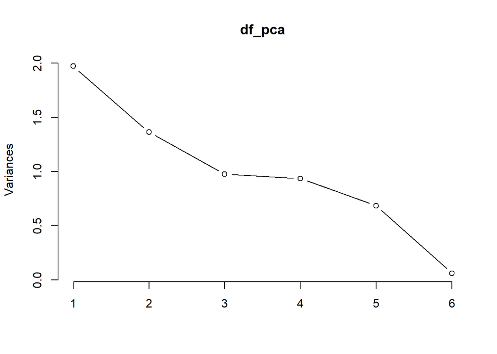

```r
plot(df_pca, type="l")
```

We can clearly see 3 is the optimal number. So let’s keep it and reintroduce the categorical data.

```r
df_pca2 <- as.data.frame(df_pca$x[,1:3])
df_pca2 <- cbind(df_pca2, df[, -c(4,5,8,30,31,32)])
str(df_pca2)
```

```
## 'data.frame':    412478 obs. of  37 variables:
##  $ PC1                      : num  0.0831 -1.0371 -1.3842 -1.4702 -2.4236 ...
##  $ PC2                      : num  -0.847 -0.203 0.462 -0.559 -0.677 ...
##  $ PC3                      : num  -0.471 0.23 0.648 0.207 -1.127 ...
##  $ State                    : num  0 0 0 0 0 0 0 0 0 0 ...
##  $ Gender                   : int  0 0 0 0 0 1 0 0 0 0 ...
##  $ GeneralHealth            : num  0.75 1 0.75 1 0.25 0 0.75 0.5 0.5 0.5 ...
##  $ LastCheckupTime          : num  1 0 1 1 1 1 1 1 1 1 ...
##  $ PhysicalActivities       : int  0 0 1 1 1 0 1 0 1 1 ...
##  $ RemovedTeeth             : int  1 1 1 1 1 1 1 1 1 1 ...
##  $ HadHeartAttack           : int  0 0 0 0 0 1 0 0 0 0 ...
##  $ HadAngina                : int  0 0 0 0 0 0 0 0 0 0 ...
##  $ HadStroke                : int  0 0 0 0 0 1 0 0 0 0 ...
##  $ HadAsthma                : int  0 0 0 1 0 0 0 0 0 0 ...
##  $ HadSkinCancer            : int  0 1 1 0 0 0 0 0 1 0 ...
```

[output cut: 23 more lines]

```r
summary(df_pca2)
```

```
##       PC1                PC2               PC3                State
##  Min.   :-5.44197   Min.   :-5.2710   Min.   :-10.97307   Min.   :0.0000
##  1st Qu.:-0.99458   1st Qu.:-0.7350   1st Qu.: -0.55907   1st Qu.:0.2830
##  Median : 0.01983   Median :-0.3985   Median :  0.03697   Median :0.4906
##  Mean   : 0.00000   Mean   : 0.0000   Mean   :  0.00000   Mean   :0.5172
##  3rd Qu.: 0.81360   3rd Qu.: 0.2977   3rd Qu.:  0.60157   3rd Qu.:0.7925
##  Max.   : 7.99661   Max.   : 5.7901   Max.   :  6.57446   Max.   :1.0000
##      Gender       GeneralHealth    LastCheckupTime  PhysicalActivities
##  Min.   :0.0000   Min.   :0.0000   Min.   :0.0000   Min.   :0.0000
##  1st Qu.:0.0000   1st Qu.:0.5000   1st Qu.:1.0000   1st Qu.:1.0000
##  Median :0.0000   Median :0.7500   Median :1.0000   Median :1.0000
##  Mean   :0.4719   Mean   :0.6168   Mean   :0.8881   Mean   :0.7699
##  3rd Qu.:1.0000   3rd Qu.:0.7500   3rd Qu.:1.0000   3rd Qu.:1.0000
##  Max.   :1.0000   Max.   :1.0000   Max.   :1.0000   Max.   :1.0000
##   RemovedTeeth    HadHeartAttack     HadAngina         HadStroke
##  Min.   :0.0000   Min.   :0.0000   Min.   :0.00000   Min.   :0.00000
##  1st Qu.:0.0000   1st Qu.:0.0000   1st Qu.:0.00000   1st Qu.:0.00000
##  Median :0.0000   Median :0.0000   Median :0.00000   Median :0.00000
##  Mean   :0.4707   Mean   :0.0558   Mean   :0.05887   Mean   :0.04267
##  3rd Qu.:1.0000   3rd Qu.:0.0000   3rd Qu.:0.00000   3rd Qu.:0.00000
##  Max.   :1.0000   Max.   :1.0000   Max.   :1.00000   Max.   :1.00000
##    HadAsthma      HadSkinCancer        HadCOPD        HadDepressiveDisorder
##  Min.   :0.0000   Min.   :0.00000   Min.   :0.00000   Min.   :0.0000
##  1st Qu.:0.0000   1st Qu.:0.00000   1st Qu.:0.00000   1st Qu.:0.0000
##  Median :0.0000   Median :0.00000   Median :0.00000   Median :0.0000
##  Mean   :0.1443   Mean   :0.08153   Mean   :0.07701   Mean   :0.1992
##  3rd Qu.:0.0000   3rd Qu.:0.00000   3rd Qu.:0.00000   3rd Qu.:0.0000
##  Max.   :1.0000   Max.   :1.00000   Max.   :1.00000   Max.   :1.0000
##  HadKidneyDisease   HadArthritis     HadDiabetes     DeafOrHardOfHearing
##  Min.   :0.00000   Min.   :0.0000   Min.   :0.0000   Min.   :0.00000
##  1st Qu.:0.00000   1st Qu.:0.0000   1st Qu.:0.0000   1st Qu.:0.00000
##  Median :0.00000   Median :0.0000   Median :0.0000   Median :0.00000
##  Mean   :0.04436   Mean   :0.3335   Mean   :0.1389   Mean   :0.08687
##  3rd Qu.:0.00000   3rd Qu.:1.0000   3rd Qu.:0.0000   3rd Qu.:0.00000
##  Max.   :1.00000   Max.   :1.0000   Max.   :1.0000   Max.   :1.00000
##  BlindOrVisionDifficulty DifficultyConcentrating DifficultyWalking
##  Min.   :0.00000         Min.   :0.0000          Min.   :0.0000
##  1st Qu.:0.00000         1st Qu.:0.0000          1st Qu.:0.0000
##  Median :0.00000         Median :0.0000          Median :0.0000
##  Mean   :0.05136         Mean   :0.1084          Mean   :0.1425
```

[output cut: 15 more lines]

```
##  Max.   :1.000   Max.   :1.0000   Max.   :1.0000   Max.   :1.0000
##   FluVaxLast12    PneumoVaxEver    TetanusLast10Tdap HighRiskLastYear
##  Min.   :0.0000   Min.   :0.0000   Min.   :0.0000    Min.   :0.00000
##  1st Qu.:0.0000   1st Qu.:0.0000   1st Qu.:1.0000    1st Qu.:0.00000
##  Median :1.0000   Median :0.0000   Median :1.0000    Median :0.00000
##  Mean   :0.5785   Mean   :0.3433   Mean   :0.8158    Mean   :0.03842
##  3rd Qu.:1.0000   3rd Qu.:1.0000   3rd Qu.:1.0000    3rd Qu.:0.00000
##  Max.   :1.0000   Max.   :1.0000   Max.   :1.0000    Max.   :1.00000
##     CovidPos                        RaceEthnicityCategory
##  Min.   :0.0000   Black only, Non-Hispanic     : 32934
##  1st Qu.:0.0000   Hispanic                     : 40998
##  Median :0.0000   Multiracial, Non-Hispanic    :  9024
##  Mean   :0.2774   Other race only, Non-Hispanic: 22004
##  3rd Qu.:1.0000   White only, Non-Hispanic     :307518
##  Max.   :1.0000
```

To simplify even more, first I will only study “HadSkinCancer” (because is the disease most impacted by ethnicity) dropping all other diseases and “RaceEthnicityCategory”.

```r
df_simple <- df_pca2[, c(1:9,14,20:37)]
str(df_simple)
```

```
## 'data.frame':    412478 obs. of  28 variables:
##  $ PC1                      : num  0.0831 -1.0371 -1.3842 -1.4702 -2.4236 ...
##  $ PC2                      : num  -0.847 -0.203 0.462 -0.559 -0.677 ...
##  $ PC3                      : num  -0.471 0.23 0.648 0.207 -1.127 ...
##  $ State                    : num  0 0 0 0 0 0 0 0 0 0 ...
##  $ Gender                   : int  0 0 0 0 0 1 0 0 0 0 ...
##  $ GeneralHealth            : num  0.75 1 0.75 1 0.25 0 0.75 0.5 0.5 0.5 ...
##  $ LastCheckupTime          : num  1 0 1 1 1 1 1 1 1 1 ...
##  $ PhysicalActivities       : int  0 0 1 1 1 0 1 0 1 1 ...
##  $ RemovedTeeth             : int  1 1 1 1 1 1 1 1 1 1 ...
##  $ HadSkinCancer            : int  0 1 1 0 0 0 0 0 1 0 ...
##  $ DeafOrHardOfHearing      : int  0 0 0 0 0 0 0 0 0 0 ...
##  $ BlindOrVisionDifficulty  : int  0 0 0 0 0 0 0 0 1 0 ...
##  $ DifficultyConcentrating  : int  0 0 0 0 0 0 0 0 0 0 ...
##  $ DifficultyWalking        : int  0 0 0 0 0 0 0 0 1 0 ...
##  $ DifficultyDressingBathing: int  0 0 0 0 0 0 0 0 0 0 ...
##  $ DifficultyErrands        : int  0 0 0 0 0 0 0 0 0 0 ...
##  $ SmokerStatus             : int  0 0 0 1 0 0 1 0 1 0 ...
##  $ ECigaretteUsage          : int  0 1 1 1 1 1 1 1 0 1 ...
##  $ ChestScan                : int  0 0 0 1 1 0 0 1 0 0 ...
##  $ AgeCategory              : num  1 1 0.583 0.75 0.333 ...
##  $ AlcoholDrinkers          : int  0 0 0 0 1 0 1 0 0 1 ...
##  $ HIVTesting               : int  0 0 0 0 0 0 0 0 1 0 ...
##  $ FluVaxLast12             : int  1 0 0 1 0 0 0 1 0 1 ...
##  $ PneumoVaxEver            : int  0 0 0 1 1 1 0 1 0 1 ...
##  $ TetanusLast10Tdap        : int  1 1 0 1 1 1 1 1 1 1 ...
##  $ HighRiskLastYear         : int  0 0 0 0 0 0 0 0 0 0 ...
##  $ CovidPos                 : int  0 0 1 0 0 0 0 0 0 0 ...
##  $ RaceEthnicityCategory    : Factor w/ 5 levels "Black only, Non-Hispanic",..: 5 5 5 5 5 5 1 5 5 5 ...
```

Hopkins statistic will tell us if our data is clusterable. I tried with the whole dataset but my computer can not handle it, so I also reduced the number of rows.

```r
set.seed(123)
idx <- sample(1:dim(df_simple)[1], 4000)
df_sample <- df_simple[idx,]
str(df_sample)
```

```
## 'data.frame':    4000 obs. of  28 variables:
##  $ PC1                      : num  -0.795 -2.494 2.265 -1.606 -1.619 ...
##  $ PC2                      : num  -0.7805 -0.0811 -0.0161 -0.3022 -0.614 ...
##  $ PC3                      : num  0.679 -0.532 -1.902 0.643 0.445 ...
##  $ State                    : num  0.453 0.377 0.321 0.415 0.566 ...
##  $ Gender                   : int  1 0 0 1 0 0 0 1 0 0 ...
##  $ GeneralHealth            : num  0.75 0.5 0.25 1 1 1 1 0.75 0.5 1 ...
##  $ LastCheckupTime          : num  1 1 1 1 1 0.5 0.5 1 1 1 ...
##  $ PhysicalActivities       : int  1 0 1 1 1 1 1 1 0 1 ...
##  $ RemovedTeeth             : int  0 1 0 1 0 0 0 0 0 1 ...
##  $ HadSkinCancer            : int  0 0 0 0 0 0 0 0 0 0 ...
##  $ DeafOrHardOfHearing      : int  0 0 0 0 0 0 0 0 0 0 ...
##  $ BlindOrVisionDifficulty  : int  0 0 0 0 0 0 0 0 0 0 ...
##  $ DifficultyConcentrating  : int  0 0 0 0 0 0 0 0 0 0 ...
##  $ DifficultyWalking        : int  0 0 1 0 0 1 0 0 0 0 ...
##  $ DifficultyDressingBathing: int  0 0 0 0 0 0 0 0 0 0 ...
##  $ DifficultyErrands        : int  0 0 0 0 0 0 0 0 0 0 ...
##  $ SmokerStatus             : int  1 0 0 1 1 0 0 0 0 0 ...
##  $ ECigaretteUsage          : int  1 1 1 1 1 1 1 1 1 1 ...
##  $ ChestScan                : int  1 1 0 0 0 0 0 1 0 0 ...
##  $ AgeCategory              : num  0.833 0.917 0.75 1 0.667 ...
##  $ AlcoholDrinkers          : int  1 0 1 1 1 1 1 1 0 1 ...
##  $ HIVTesting               : int  0 0 0 0 1 0 0 0 1 0 ...
##  $ FluVaxLast12             : int  1 0 1 1 1 1 1 1 0 1 ...
##  $ PneumoVaxEver            : int  1 0 1 1 0 1 0 0 0 0 ...
##  $ TetanusLast10Tdap        : int  1 1 1 1 1 1 1 1 1 1 ...
##  $ HighRiskLastYear         : int  0 0 0 0 0 0 0 0 0 0 ...
##  $ CovidPos                 : int  1 0 0 0 1 0 0 0 0 1 ...
##  $ RaceEthnicityCategory    : Factor w/ 5 levels "Black only, Non-Hispanic",..: 5 5 5 5 5 5 5 5 3 5 ...
```

```r
print(paste("This sample dataset has", length(unique(df_sample$RaceEthnicityCategory)), "unique ethnicities."))
```

```
## [1] "This sample dataset has 5 unique ethnicities."
```

```r
library(factoextra)
```

```r
res <- get_clust_tendency(df_sample[1:27], n = nrow(df_sample)-1, graph = FALSE)
res$hopkins_stat
```

```
## [1] 0.6956715
```

H ≈ 0.7, in the next steps I will try to determine the number of clusters and if the coincide with the number of unique ethnicities.

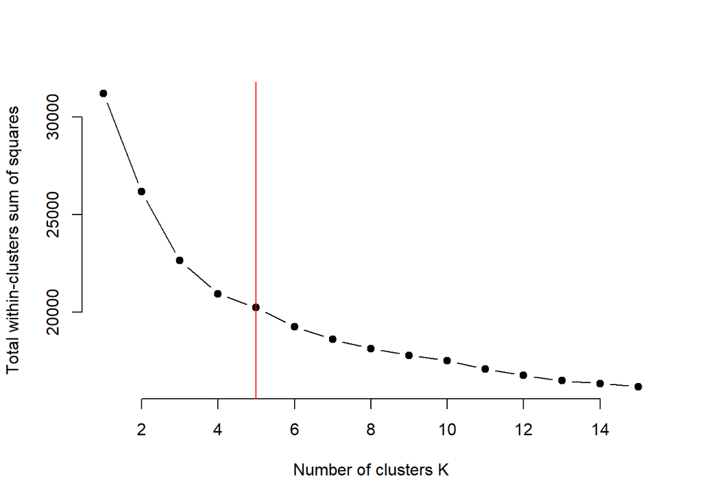

```r
set.seed(123)

k.max <- 15 # Maximal number of clusters

wss <- sapply(1:k.max,
              function(k){kmeans(df_sample[1:27], k)$tot.withinss})

plot(1:k.max, wss,
     type="b", pch = 19, frame = FALSE,
     xlab="Number of clusters K",
     ylab="Total within-clusters sum of squares")
abline(v = 5, col = "red")
```

```r
set.seed(123)

k.max <- 15

kmeans_result <- kmeans(df_sample[1:27], 5)

df_sample$cluster <- kmeans_result$cluster

print(df_sample)
```

[output not shown]

[output cut: 24129 more lines]

Now it is only a matter of counting both variables and checking how similar they are.

```r
print("Ethnicity count:")
```

```
## [1] "Ethnicity count:"
```

```r
table(df_sample$RaceEthnicityCategory)
```

```
##
##      Black only, Non-Hispanic                      Hispanic
##                           334                           386
##     Multiracial, Non-Hispanic Other race only, Non-Hispanic
##                            86                           237
##      White only, Non-Hispanic
##                          2957
```

```r
print("Cluster count:")
```

```
## [1] "Cluster count:"
```

```r
table(df_sample$cluster)
```

```
##
##    1    2    3    4    5
## 1099  909  879  578  535
```

```r
print("Ethnicity x Cluster count:")
```

```
## [1] "Ethnicity x Cluster count:"
```

```r
table(df_sample$RaceEthnicityCategory, df_sample$cluster)
```

```
##
##                                   1   2   3   4   5
##   Black only, Non-Hispanic       84  61  80  51  58
##   Hispanic                       78  88 115  49  56
##   Multiracial, Non-Hispanic      25  14  22  12  13
##   Other race only, Non-Hispanic  67  68  45  18  39
##   White only, Non-Hispanic      845 678 617 448 369
```

This makes it clear that the clusters have no relationship with ethnicities, since every ethnicity appears in every cluster and vice versa. It is true that this is a very small random sample, and perhaps with other seeds, satisfactory results could be obtained, but due to the computational cost of the algorithms, it is not feasible. We have already seen through linear regression and hclust that although ethnicities do influence the probability of suffering (or not) from certain diseases, they are not a highly determining factor for it.